# Why is less distance better?

Austin Stephen

7/8/2021

## Why is there an inverse correlation with wins and distance?

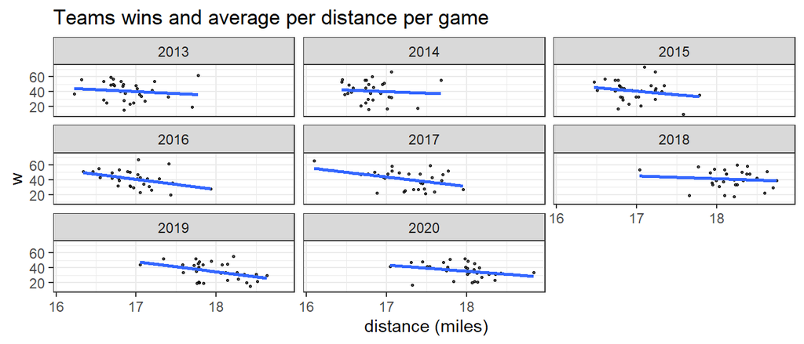

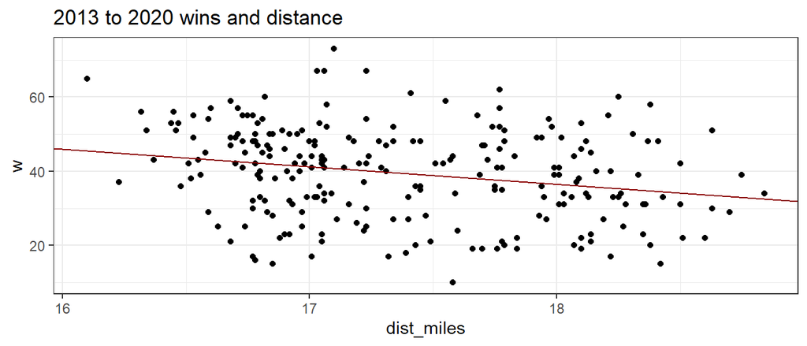

y = 121.6 + -4.73  
p-value: .00018 and adj r-squared: .053

### 2018

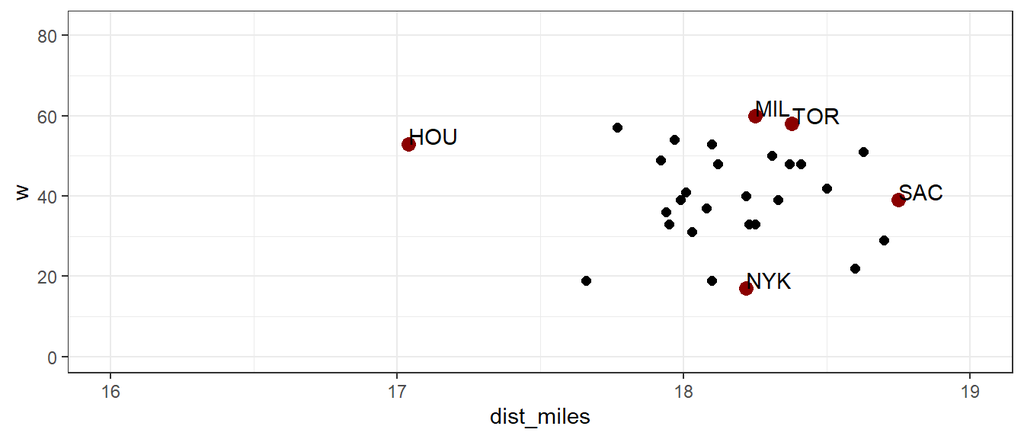

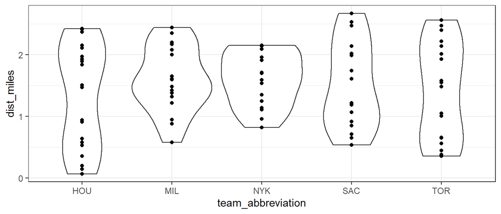

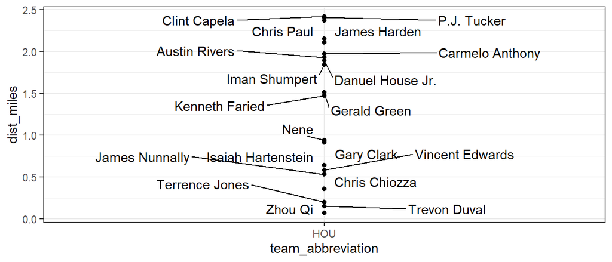

### 2017

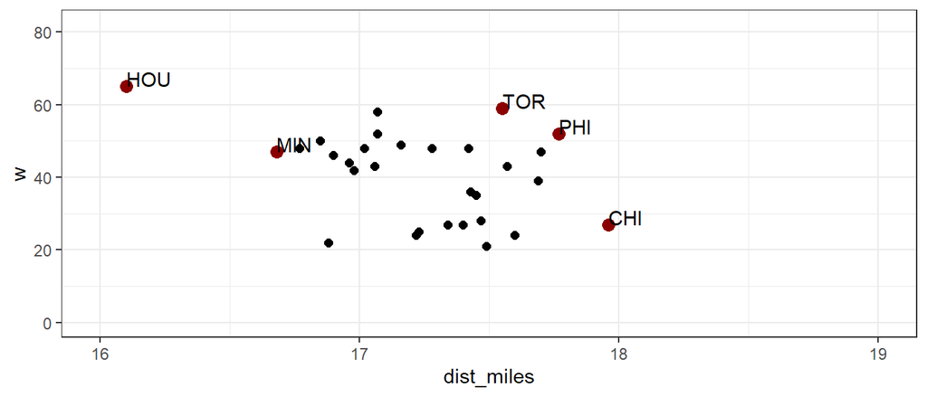

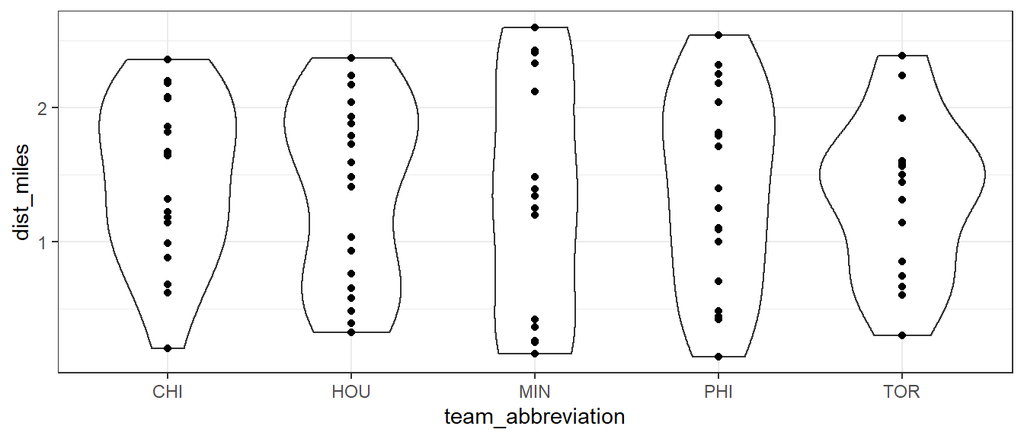

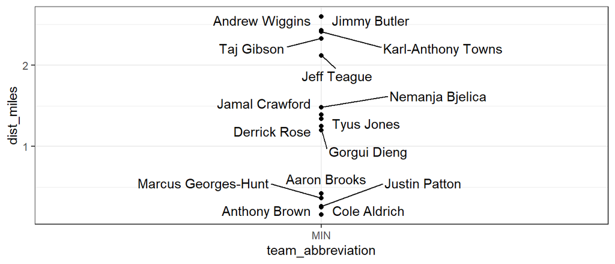

I don’t really see any relationship in 2017.

### 2016

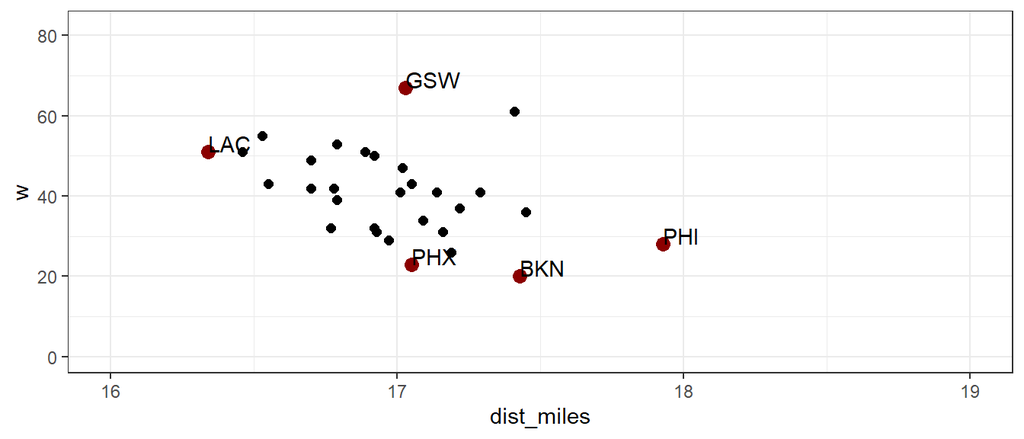

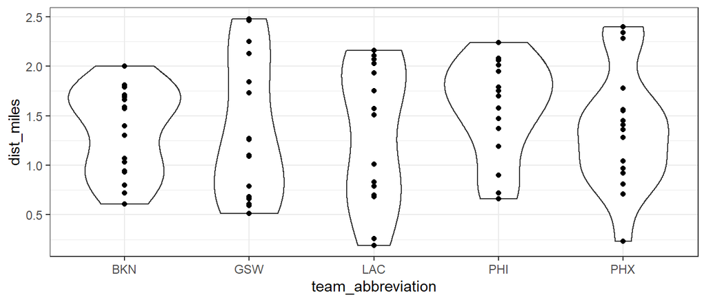

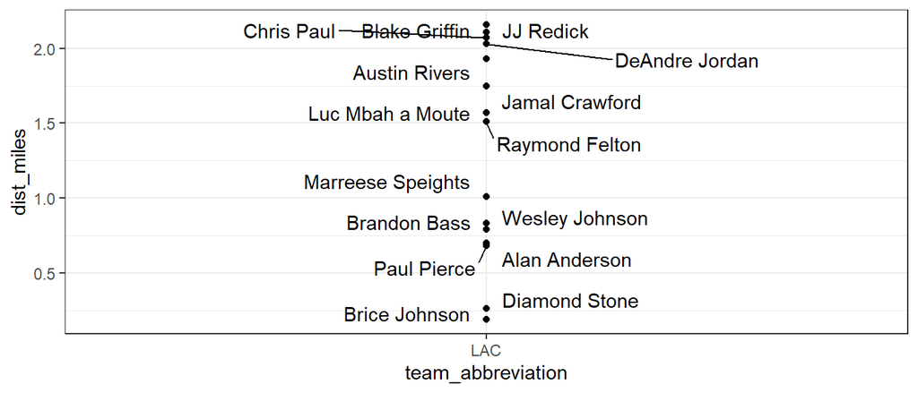

### Offensive distance accounts for most of the association with wins

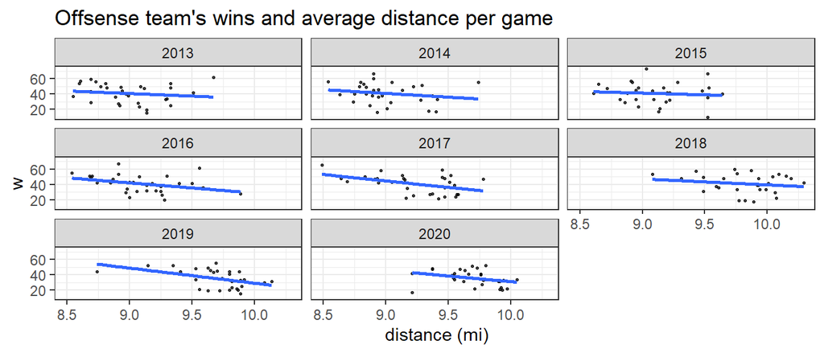

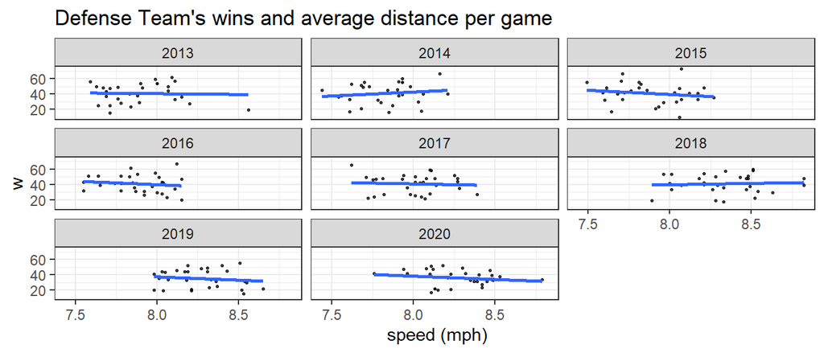

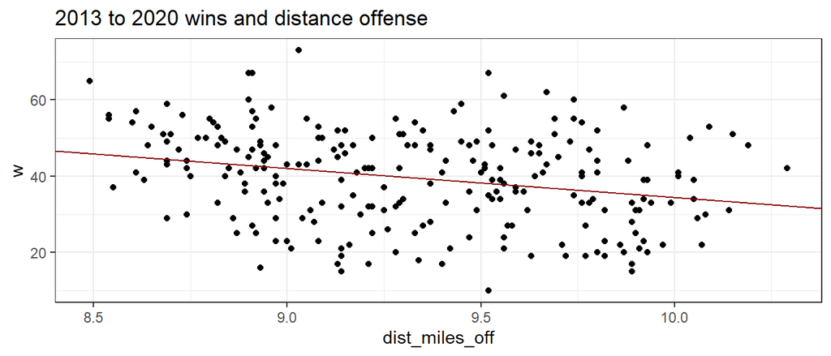

Linear model w ~ offense_distance  
p-value: 2.4 *10-5  
adj r-squared: 0.065

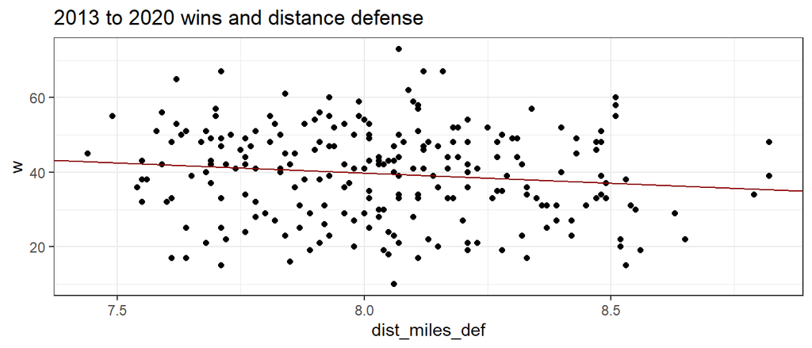

Linear model w ~ defense_distance  
p-value: 0.048  
adj r-squared: 0.012

Significant relationship between distance on offense and wins. A negative or neutral relationship between distance on defense and wins. This means it is probably linked to some type of offensive statistic.

## How distance relates with other offensive statistics

### Three Point Percentage

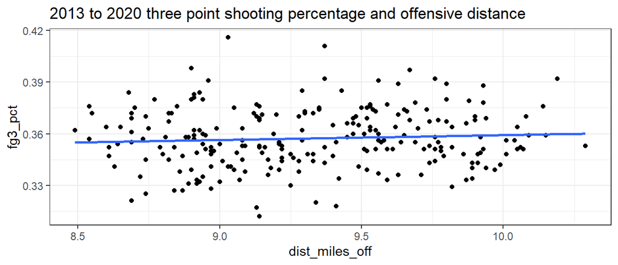

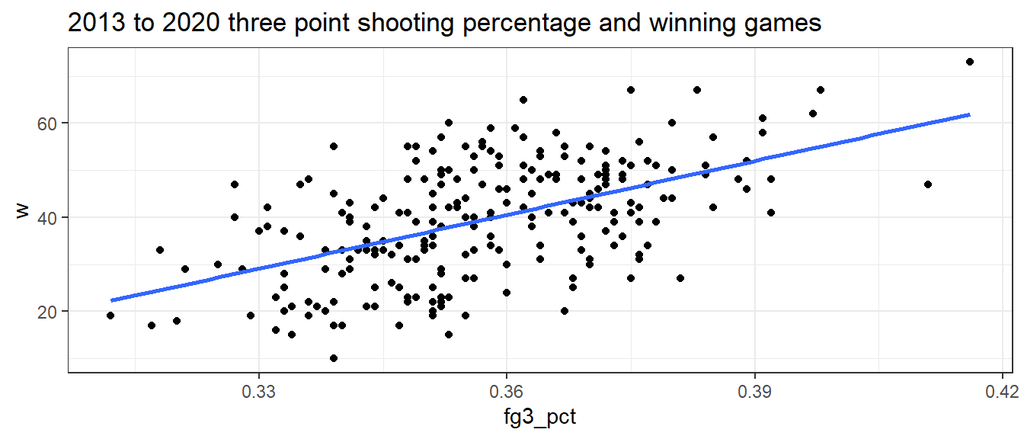

There appears to be a slight positive or no relationship with three point shooting and distance but this is in the opposite direction of the trend with distance and wins. This is impressive because three point shooting is very strongly linked to wins which means the association we saw with distance overcame this relationship.

### Field Goal Percentage

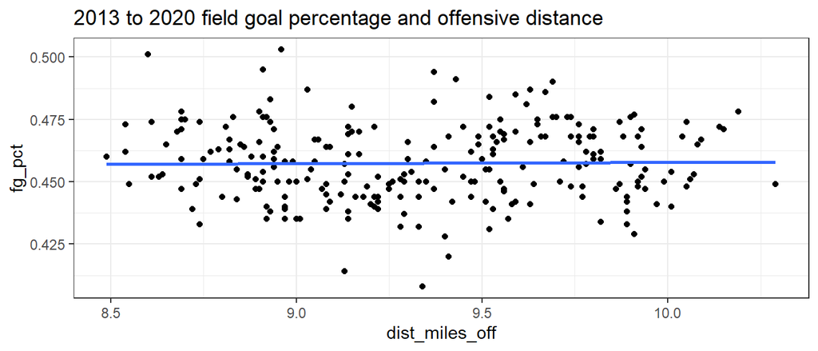

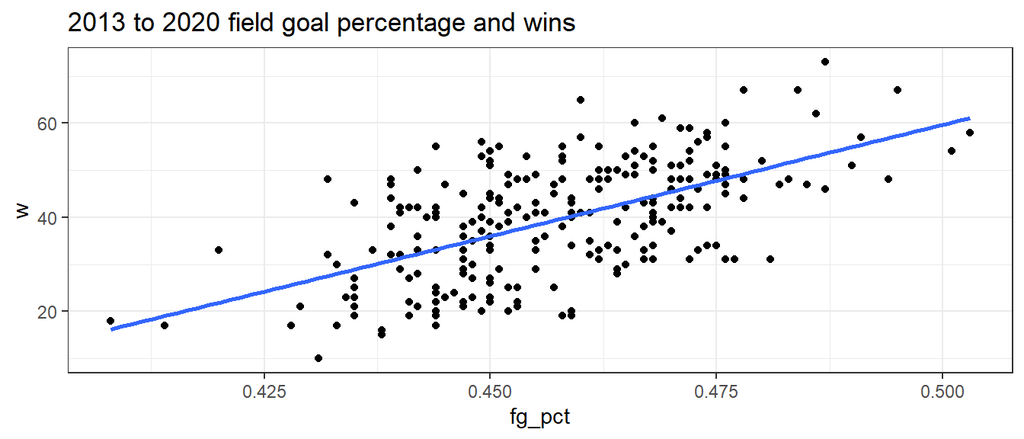

Shooting percentage appears to have no relationship with team distance and is clearly linked to winning games as expected.

### Offensive Rebounds

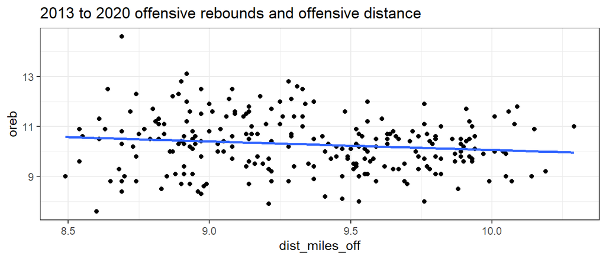

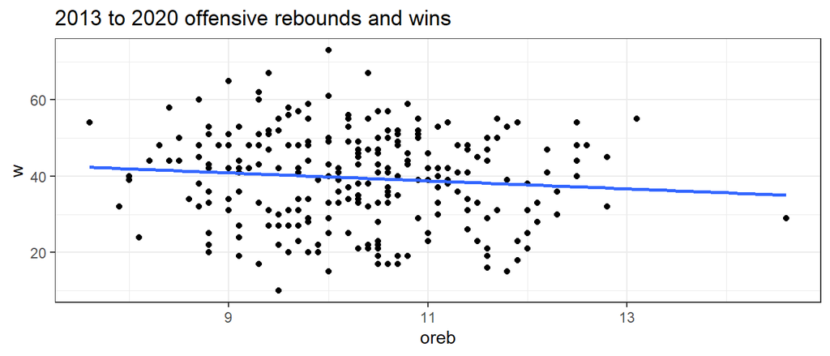

Appears to be a slight negative correlation between offensive rebounds and distance which is initially promising. However, offensive rebounds has a negative association with wins so this acts to counteract the net effect of distance we are looking to explain. Also, we know getting offensive rebounds does not make a team worse so it must have to do with missing more shots enables more offensive rebounds. Overall, this does not help explain the effect.

### Turnovers

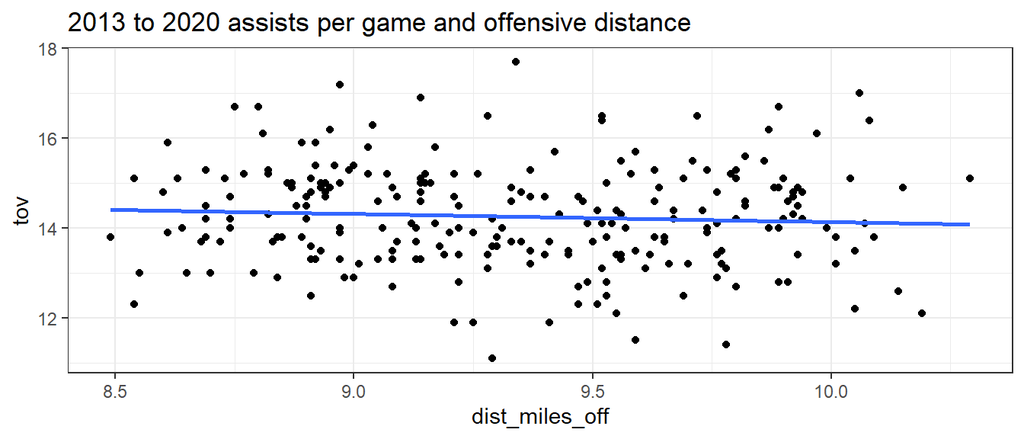

No relationship.

### Assists

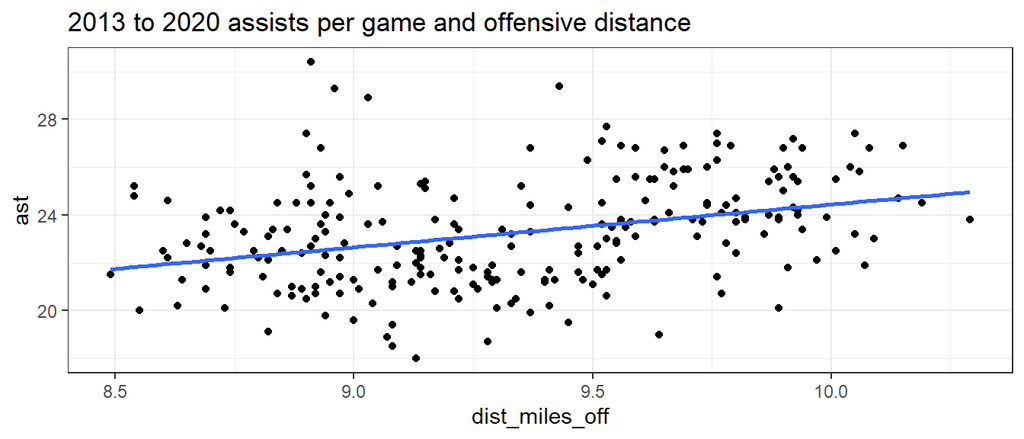

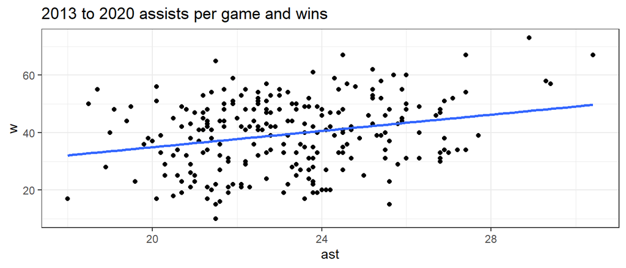

Assists and distance:  
p-value: 4.7 * 10^-8  
r-squared: 0.118

Assists and wins:  
p-value: 5.854e-05 r-squared: 0.06574

There is a significant positive relationship between distance and assists. Also, there is a significant positive relationship between assists and wins. This is the opposite of what we would expect to see because it means distance had to overcome this relationship to get the negative correlation we saw.

[figure not shown]